# Analyses of GSE121575

# Hippuristanol vs Naive (Pulldown)

## Volcano Plot

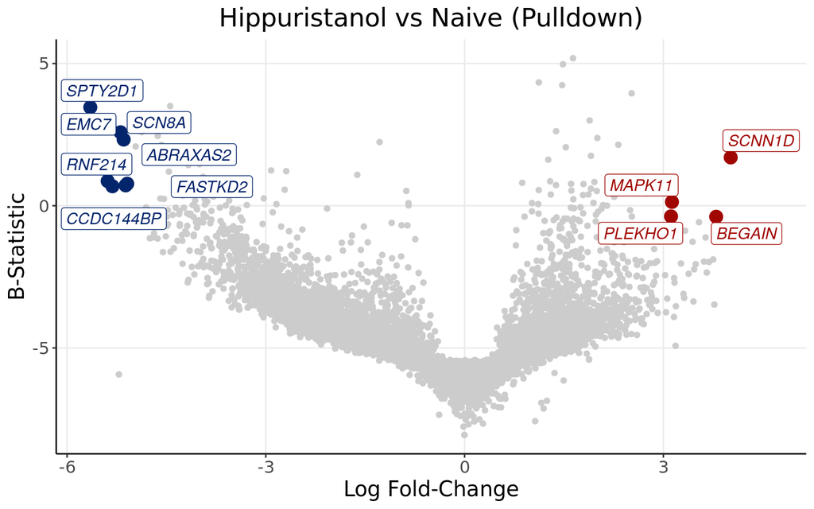

```r
write.table(x = DEGenes_HipvsNai,
            file = "~/Projects/StressGranules/SGPAPER/SGvsWC/APadron_Hippuristanol.txt", sep="\t", col.names = TRUE, row.names = TRUE, quote=FALSE)

upmarkers <- as.data.frame(DEGenes_HipvsNai[DEGenes_HipvsNai$logFC>3 & DEGenes_HipvsNai$adj.P.Val<0.05,] )
downmarkers <- as.data.frame(DEGenes_HipvsNai[DEGenes_HipvsNai$logFC< -5 & DEGenes_HipvsNai$adj.P.Val<0.05,] )

ggplot(data=DEGenes_HipvsNai,
                 aes(x=logFC,
                     y=  B)) +
  geom_point(color="#CCCCCC")+
  theme_bw() + ylab("B-Statistic")+xlab("Log Fold-Change")+
  theme(axis.line = element_line(colour = "black"),
        panel.grid.minor = element_blank(),
        panel.border = element_blank(),
        panel.background = element_blank()) +
  ggtitle("Hippuristanol vs Naive (Pulldown)")+
  theme(plot.title = element_text(hjust = 0.5), plot.subtitle = element_text(hjust = 0.5)) +
  geom_point(data=upmarkers, aes(x=logFC, y=  B), color="#A10702",size=4)+
  geom_point(data=downmarkers, aes(x=logFC, y=  B), color="#03256C",size=4)+
  geom_label_repel(upmarkers[1:ndegs,] , mapping=aes(label=row.names(upmarkers)[1:ndegs]),size=4,point.padding=-0.5, color="#A10702",max.overlaps = 20, fontface="italic")+
  geom_label_repel(downmarkers[1:ndegs,] , mapping=aes(label=row.names(downmarkers)[1:ndegs]),size=4,point.padding=-0.5, color="#03256C",max.overlaps = 20, fontface="italic")+
  theme(text=element_text(size=15,  family="Arial MS"))
```

## Volcano Plot with Gene Length

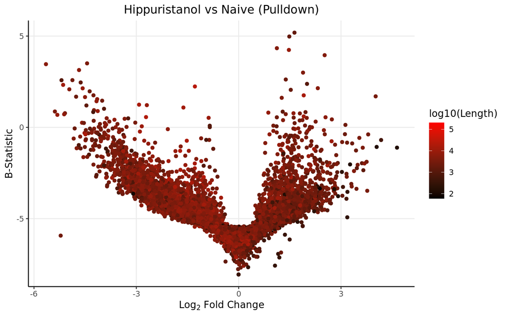

```r
DEGenes_HipvsNai$Gene <- row.names(DEGenes_HipvsNai)
colnames(genelength) <- c("Length","Gene")
DEGenes_HipvsNai <- merge(DEGenes_HipvsNai, genelength, by="Gene")

ggplot(data=DEGenes_HipvsNai,
                 aes(x=logFC,
                     y=  B)) +
  geom_point(aes(color=log10(Length)))+
  theme_bw() +
  theme(axis.line = element_line(colour = "black"),
        panel.grid.minor = element_blank(),
        panel.border = element_blank(),
        panel.background = element_blank()) +
  ggtitle("Hippuristanol vs Naive (Pulldown)")+ xlab(expression(Log[2] ~ Fold ~ Change)) + ylab("B-Statistic") +
  theme(plot.title = element_text(hjust = 0.5))  +
  scale_colour_gradient(low = "black", high = "red")+ theme(text=element_text(family = "Quicksand"))
```

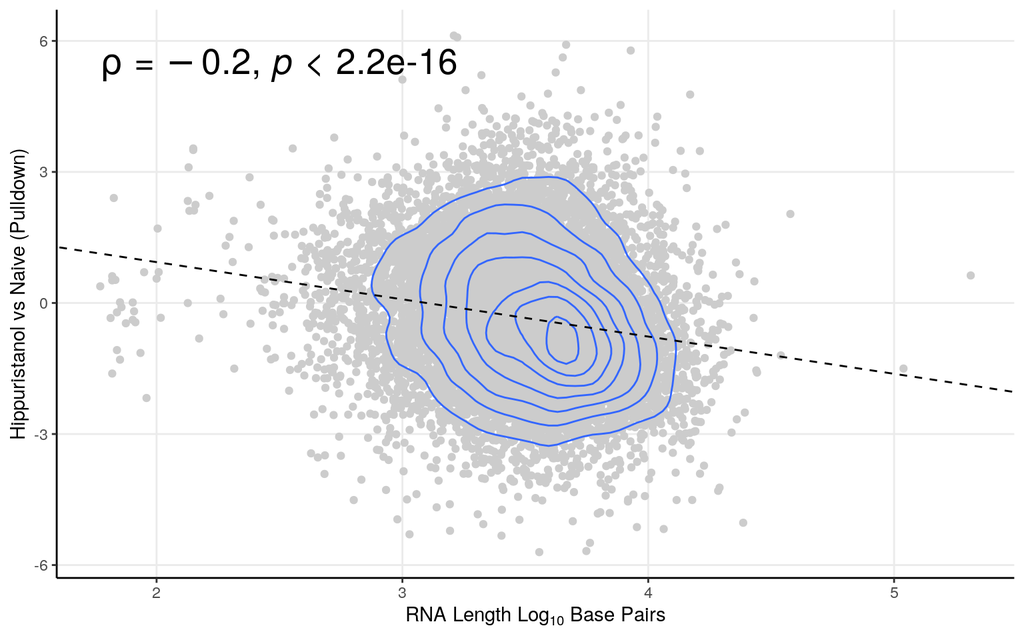

```r
smooth.SG <- lm(t~log10(Length), DEGenes_HipvsNai)
liner.SG <- rstandard(smooth.SG)
DEGenes_HipvsNai <-cbind(DEGenes_HipvsNai, liner.SG)
colnames(DEGenes_HipvsNai)[9] <- "Residuals"
row.names(DEGenes_HipvsNai) <- DEGenes_HipvsNai$Gene
linemarkers <- as.data.frame(DEGenes_HipvsNai[abs(DEGenes_HipvsNai$Residuals)>4,])

# Calculate the Spearman correlation coefficient
spearman_corr <- cor(DEGenes_HipvsNai$t, log10(DEGenes_HipvsNai$Length), method = "spearman")



ggplot(DEGenes_HipvsNai, aes(y=t, x=log10(Length))) + geom_point(color="#CCCCCC", alpha=1) +   theme_bw()+ geom_density_2d()+
 ylab("Hippuristanol vs Naive (Pulldown)") + xlab(expression(RNA ~ Length ~ Log[10] ~ Base ~ Pairs)) +
  theme(axis.line = element_line(colour = "black"),
        panel.grid.minor = element_blank(),
        panel.border = element_blank(),
        panel.background = element_blank()) +
  theme(plot.title = element_text(hjust = 0.5))  +
  geom_abline(slope=smooth.SG$coefficients[2], intercept = smooth.SG$coefficients[1], linetype = "dashed")+ stat_cor(method = "spearman", cor.coef.name = "rho",size=7)
```

## Expression Graphs (Extra QC)

As an added control, lets plot these genes in regard to their expression, and contamination.

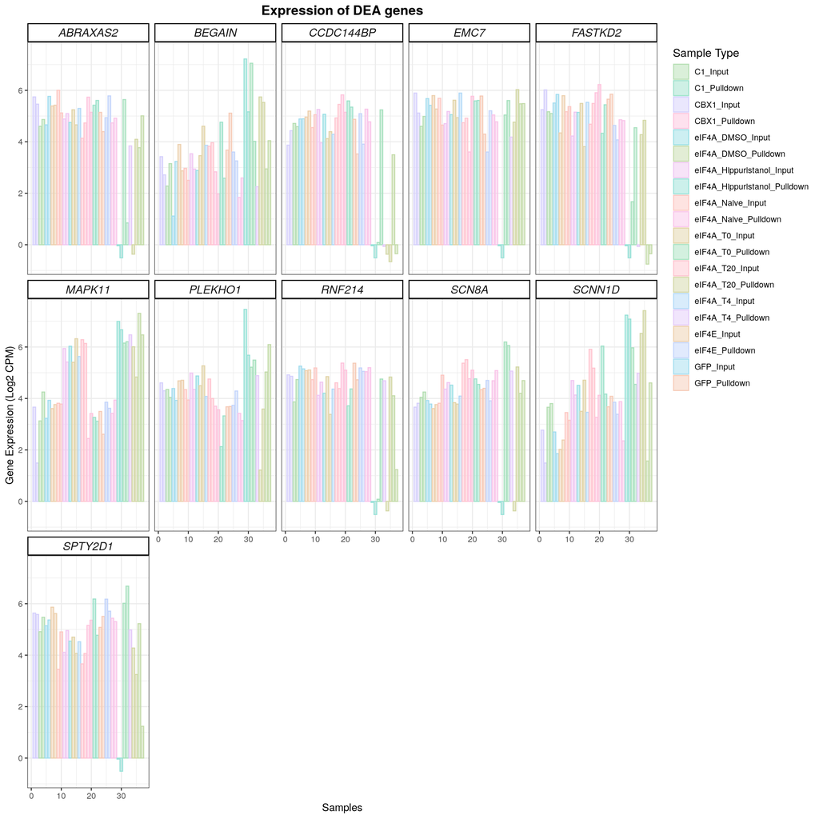

```r
# Define color palette
custom_palette <- qualitative_hcl(20, palette = "Pastel")
custom_palette <- sample(custom_palette, 20)


upmarkers <- as.data.frame(DEGenes_HipvsNai[DEGenes_HipvsNai$logFC>3 & DEGenes_HipvsNai$adj.P.Val<0.05,] )
downmarkers <- as.data.frame(DEGenes_HipvsNai[DEGenes_HipvsNai$logFC< -5 & DEGenes_HipvsNai$adj.P.Val<0.05,] )

finagenes <- rbind(upmarkers, downmarkers)

dfforexpression <- dfforpca
samplecodes <- data.frame(samples=row.names(dfforexpression), purity=c(1:nrow(dfforexpression)))
sampletype <- data.frame(samples=row.names(dfforexpression), sampletype=forall)
dfforexpression <- t(dfforexpression)
genesforexp <- dfforexpression[row.names(dfforexpression)%in%row.names(finagenes),]
genesforexp <- reshape2::melt(genesforexp)
colnames(genesforexp) <- c("Gene", "samples", "expression")
genesforexp <- merge(genesforexp, samplecodes, by="samples")
genesforexp <- merge(genesforexp, sampletype, by="samples")
genesforexp <- genesforexp[,-1]
genesforexp[,2] <- as.numeric(genesforexp[,2])
genesforexp[,1] <- as.character(genesforexp[,1])
genesforexp <- genesforexp[order(genesforexp$Gene),]


winnyplot <- ggplot(genesforexp, aes(x=purity, y=expression, fill=sampletype, colour=sampletype)) + geom_bar(position="dodge", stat="identity", alpha=0.5) + facet_wrap(.~ Gene, ncol=5)
winnyplot <- winnyplot + scale_fill_manual(name = "Sample Type", values = custom_palette) + scale_colour_manual(name = "Sample Type", values = custom_palette)
winnyplot <- winnyplot + theme_bw() + xlab("Samples") + ylab("Gene Expression (Log2 CPM)") + theme(
      strip.text.x = element_text(
        size = 12, face="italic"
        )) +
 theme(
   strip.background = element_rect(
     color="black", fill="#FFFFFF", size=1, linetype="solid"
     )
   ) + theme(
    #legend.position = c(.95, .40),
    legend.justification = c("right", "top"),
    legend.box.just = "right",
    ) + theme(legend.title = element_text(size = 12)) + ggtitle("Expression of DEA genes") + theme(plot.title = element_text(hjust = 0.5, size=14, face="bold"))
winnyplot
```

## GSEA

```r
#for all genes
DEGenes_HipvsNai <- DEGenes_HipvsNai[order(DEGenes_HipvsNai[,4]),]
gseatool <- DEGenes_HipvsNai[,4]
gseatool <- as.data.frame(gseatool)
colnames(gseatool)[1] <- "t"
gseatool[,2] <- DEGenes_HipvsNai$Gene
colnames(gseatool)[2] <- "Symbol"
gseatool <- gseatool[,c(2,1)]

vectorranks <- gseatool$t
names(vectorranks) <- gseatool$Symbol


#to load our pathways
hallmarks.gs <- msigdbr(species = "Homo sapiens", collection =  "H")

hallmarks.gsets <- hallmarks.gs %>% split(x = .$gene_symbol, f = .$gs_name)

for (set in names(hallmarks.gsets)){
  hallmarks.gsets[[set]] <- toupper(hallmarks.gsets[[set]])
}

hallmarks.res <- fgsea(pathways = hallmarks.gsets,
                       stats = vectorranks)
```

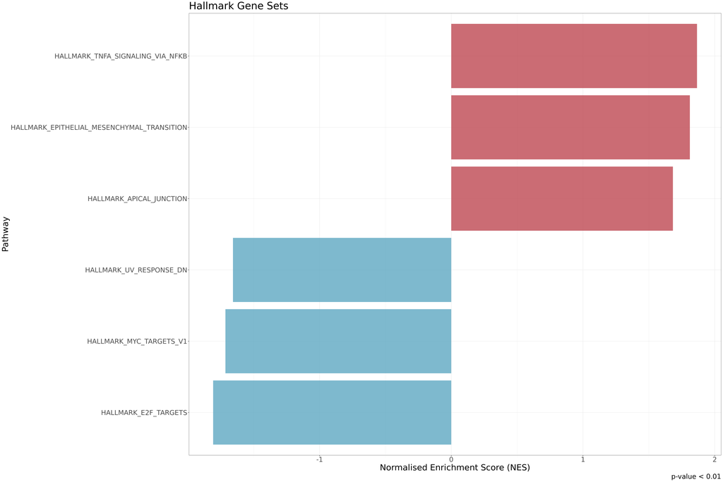

```r
hallmarks.res.tidy <- hallmarks.res %>%
  as_tibble() %>%
  arrange(desc(NES))

hallmarks.res.tidy %>%
  dplyr::select(-leadingEdge, -ES) %>%
  arrange(padj)

hallmark.sg.t <- hallmarks.res.tidy[,c(1,6)]
hallmark.sg.t <- as.data.frame(hallmark.sg.t)

#this small part is generic
thresh <- 0.01

#this one is no longer generic
data_to_plot <- hallmarks.res.tidy %>% filter(padj < thresh)

statvec <- c()
for (i in 1:nrow(data_to_plot)){
  if (data_to_plot[i,6] > 0){
    status <- "Upregulated"
  }
 else {
   status <- "Downregulated"
 }
statvec <- c(statvec, status)
}

data_to_plot$Status <- statvec

##-----HALMARK-----
gsea_plot_hall <- ggplot(data_to_plot, aes(reorder(pathway, NES), NES)) +
  geom_col(aes(fill= Status), alpha=0.75) + scale_fill_manual(values = c("#53A2BE","#BA3B46"), name = "Regulation Status", labels = c("Downregulated", "Upregulated"), breaks = c("Downregulated", "Upregulated")) +
  coord_flip() +
  labs(x="Pathway", y="Normalised Enrichment Score (NES)",
       title= "Hallmark Gene Sets",
       caption = paste0("p-value < ", thresh)) + theme(plot.title = element_text(hjust = 1)) +
  theme_bw() + theme(text=element_text(family = "Quicksand")) + theme(legend.position = "none")

gsea_plot_hall+
  theme(text=element_text(size=25,  family="Arial MS"))
```

# Hippuristanol vs Hippuristanol

## Volcano Plot

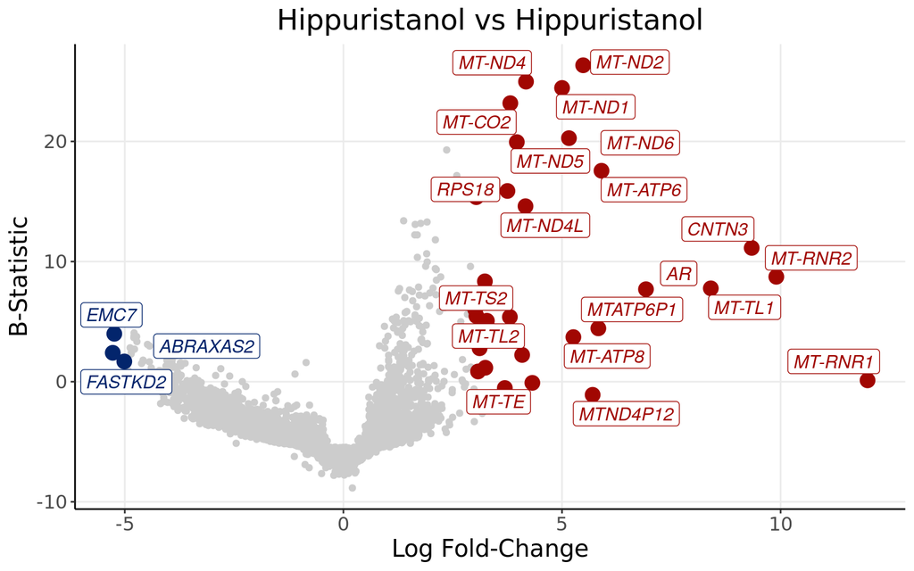

```r
upmarkers <- as.data.frame(DEGenes_HipvsHip[DEGenes_HipvsHip$logFC>3 & DEGenes_HipvsHip$adj.P.Val<0.05,] )
downmarkers <- as.data.frame(DEGenes_HipvsHip[DEGenes_HipvsHip$logFC< -5 & DEGenes_HipvsHip$adj.P.Val<0.05,] )

ggplot(data=DEGenes_HipvsHip,
                 aes(x=logFC,
                     y=  B)) +
  geom_point(color="#CCCCCC")+
  theme_bw() + ylab("B-Statistic")+xlab("Log Fold-Change")+
  theme(axis.line = element_line(colour = "black"),
        panel.grid.minor = element_blank(),
        panel.border = element_blank(),
        panel.background = element_blank()) +
  ggtitle("Hippuristanol vs Hippuristanol")+
  theme(plot.title = element_text(hjust = 0.5), plot.subtitle = element_text(hjust = 0.5)) +
  geom_point(data=upmarkers, aes(x=logFC, y=  B), color="#A10702",size=4)+
  geom_point(data=downmarkers, aes(x=logFC, y=  B), color="#03256C",size=4)+
  geom_label_repel(upmarkers[1:ndegs,] , mapping=aes(label=row.names(upmarkers)[1:ndegs]),size=4,point.padding=-0.5, color="#A10702",max.overlaps = 20, fontface="italic")+
  geom_label_repel(downmarkers[1:ndegs,] , mapping=aes(label=row.names(downmarkers)[1:ndegs]),size=4,point.padding=-0.5, color="#03256C",max.overlaps = 20, fontface="italic")+
  theme(text=element_text(size=15,  family="Arial MS"))
```

## Volcano Plot with Gene Length

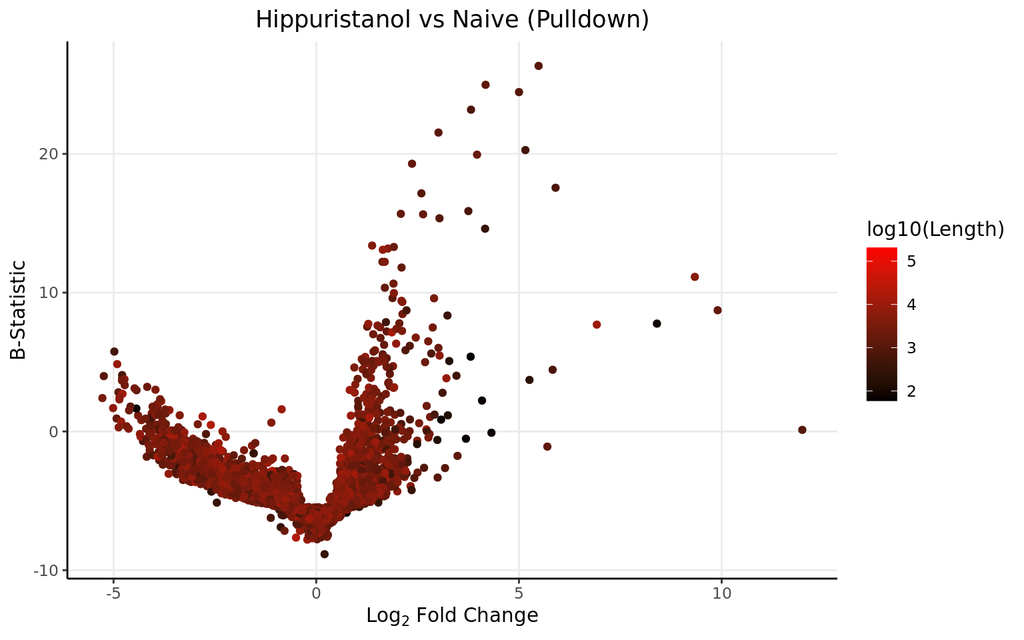

```r
DEGenes_HipvsHip$Gene <- row.names(DEGenes_HipvsHip)
colnames(genelength) <- c("Length","Gene")
DEGenes_HipvsHip <- merge(DEGenes_HipvsHip, genelength, by="Gene")

ggplot(data=DEGenes_HipvsHip,
                 aes(x=logFC,
                     y=  B)) +
  geom_point(aes(color=log10(Length)))+
  theme_bw() +
  theme(axis.line = element_line(colour = "black"),
        panel.grid.minor = element_blank(),
        panel.border = element_blank(),
        panel.background = element_blank()) +
  ggtitle("Hippuristanol vs Naive (Pulldown)")+ xlab(expression(Log[2] ~ Fold ~ Change)) + ylab("B-Statistic") +
  theme(plot.title = element_text(hjust = 0.5))  +
  scale_colour_gradient(low = "black", high = "red")+ theme(text=element_text(family = "Quicksand"))
```

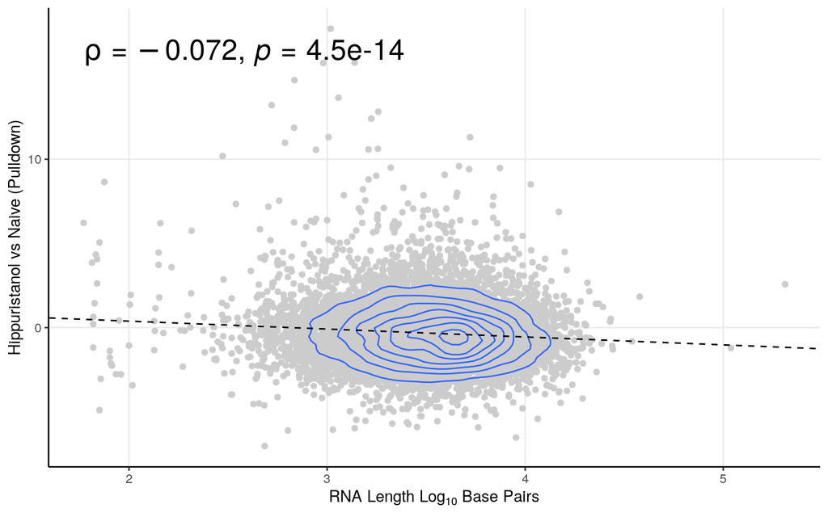

```r
smooth.SG <- lm(t~log10(Length), DEGenes_HipvsHip)
liner.SG <- rstandard(smooth.SG)
DEGenes_HipvsHip <-cbind(DEGenes_HipvsHip, liner.SG)
colnames(DEGenes_HipvsHip)[9] <- "Residuals"
row.names(DEGenes_HipvsHip) <- DEGenes_HipvsHip$Gene
linemarkers <- as.data.frame(DEGenes_HipvsHip[abs(DEGenes_HipvsHip$Residuals)>4,])

# Calculate the Spearman correlation coefficient
spearman_corr <- cor(DEGenes_HipvsHip$t, log10(DEGenes_HipvsHip$Length), method = "spearman")



ggplot(DEGenes_HipvsHip, aes(y=t, x=log10(Length))) + geom_point(color="#CCCCCC", alpha=1) +   theme_bw()+ geom_density_2d()+
 ylab("Hippuristanol vs Naive (Pulldown)") + xlab(expression(RNA ~ Length ~ Log[10] ~ Base ~ Pairs)) +
  theme(axis.line = element_line(colour = "black"),
        panel.grid.minor = element_blank(),
        panel.border = element_blank(),
        panel.background = element_blank()) +
  theme(plot.title = element_text(hjust = 0.5))  +
  geom_abline(slope=smooth.SG$coefficients[2], intercept = smooth.SG$coefficients[1], linetype = "dashed")+ stat_cor(method = "spearman", cor.coef.name = "rho",size=7)
```

Mirroring the other stress, I dont see a lenght bias.

## Expression Graphs (Extra QC)

As an added control, lets plot these genes in regard to their expression, and contamination.

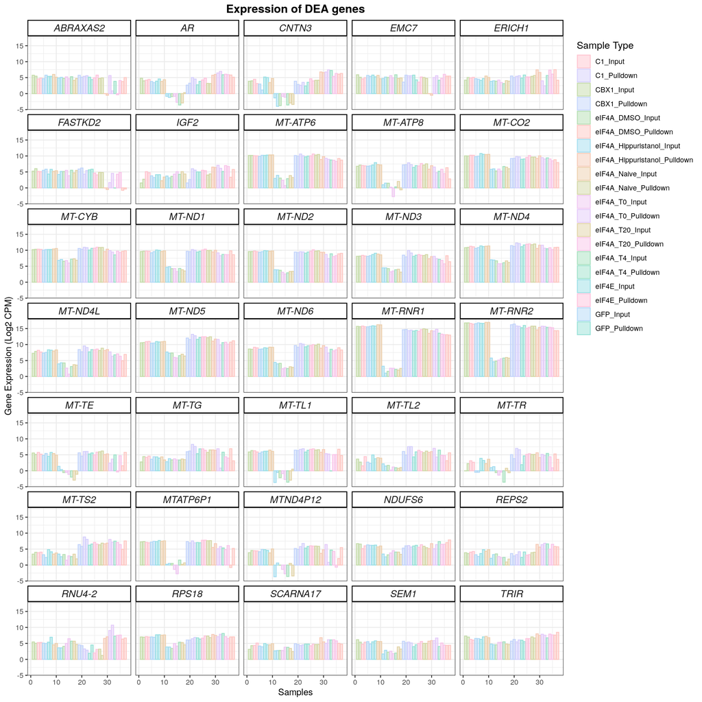

```r
# Define color palette
custom_palette <- qualitative_hcl(20, palette = "Pastel")
custom_palette <- sample(custom_palette, 20)


upmarkers <- as.data.frame(DEGenes_HipvsHip[DEGenes_HipvsHip$logFC>3 & DEGenes_HipvsHip$adj.P.Val<0.05,] )
downmarkers <- as.data.frame(DEGenes_HipvsHip[DEGenes_HipvsHip$logFC< -5 & DEGenes_HipvsHip$adj.P.Val<0.05,] )

finagenes <- rbind(upmarkers, downmarkers)

dfforexpression <- dfforpca
samplecodes <- data.frame(samples=row.names(dfforexpression), purity=c(1:nrow(dfforexpression)))
sampletype <- data.frame(samples=row.names(dfforexpression), sampletype=forall)
dfforexpression <- t(dfforexpression)
genesforexp <- dfforexpression[row.names(dfforexpression)%in%row.names(finagenes),]
genesforexp <- reshape2::melt(genesforexp)
colnames(genesforexp) <- c("Gene", "samples", "expression")
genesforexp <- merge(genesforexp, samplecodes, by="samples")
genesforexp <- merge(genesforexp, sampletype, by="samples")
genesforexp <- genesforexp[,-1]
genesforexp[,2] <- as.numeric(genesforexp[,2])
genesforexp[,1] <- as.character(genesforexp[,1])
genesforexp <- genesforexp[order(genesforexp$Gene),]


winnyplot <- ggplot(genesforexp, aes(x=purity, y=expression, fill=sampletype, colour=sampletype)) + geom_bar(position="dodge", stat="identity", alpha=0.5) + facet_wrap(.~ Gene, ncol=5)
winnyplot <- winnyplot + scale_fill_manual(name = "Sample Type", values = custom_palette) + scale_colour_manual(name = "Sample Type", values = custom_palette)
winnyplot <- winnyplot + theme_bw() + xlab("Samples") + ylab("Gene Expression (Log2 CPM)") + theme(
      strip.text.x = element_text(
        size = 12, face="italic"
        )) +
 theme(
   strip.background = element_rect(
     color="black", fill="#FFFFFF", size=1, linetype="solid"
     )
   ) + theme(
    #legend.position = c(.95, .40),
    legend.justification = c("right", "top"),
    legend.box.just = "right",
    ) + theme(legend.title = element_text(size = 12)) + ggtitle("Expression of DEA genes") + theme(plot.title = element_text(hjust = 0.5, size=14, face="bold"))
winnyplot
```

## GSEA

```r
#for all genes
DEGenes_HipvsHip <- DEGenes_HipvsHip[order(DEGenes_HipvsHip[,4]),]
gseatool <- DEGenes_HipvsHip[,4]
gseatool <- as.data.frame(gseatool)
colnames(gseatool)[1] <- "t"
gseatool[,2] <- DEGenes_HipvsHip$Gene
colnames(gseatool)[2] <- "Symbol"
gseatool <- gseatool[,c(2,1)]

vectorranks <- gseatool$t
names(vectorranks) <- gseatool$Symbol


#to load our pathways
hallmarks.gs <- msigdbr(species = "Homo sapiens", collection =  "H")

hallmarks.gsets <- hallmarks.gs %>% split(x = .$gene_symbol, f = .$gs_name)

for (set in names(hallmarks.gsets)){
  hallmarks.gsets[[set]] <- toupper(hallmarks.gsets[[set]])
}

hallmarks.res <- fgsea(pathways = hallmarks.gsets,
                       stats = vectorranks)
```

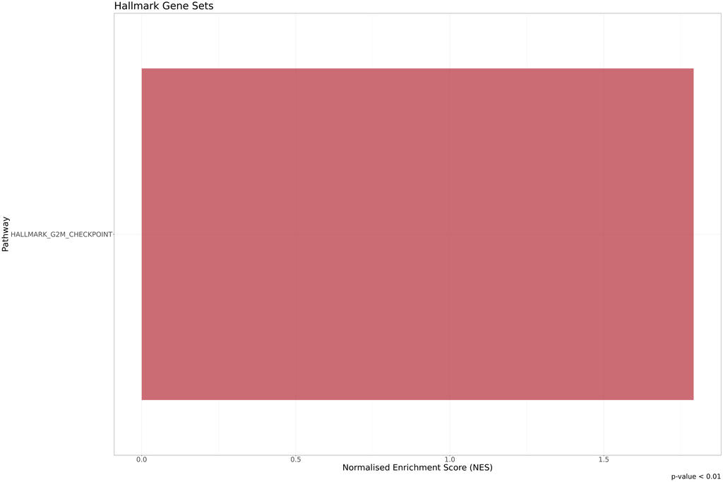

```r
hallmarks.res.tidy <- hallmarks.res %>%
  as_tibble() %>%
  arrange(desc(NES))

hallmarks.res.tidy %>%
  dplyr::select(-leadingEdge, -ES) %>%
  arrange(padj)

hallmark.sg.t <- hallmarks.res.tidy[,c(1,6)]
hallmark.sg.t <- as.data.frame(hallmark.sg.t)

#this small part is generic
thresh <- 0.01

#this one is no longer generic
data_to_plot <- hallmarks.res.tidy %>% filter(padj < thresh)

statvec <- c()
for (i in 1:nrow(data_to_plot)){
  if (data_to_plot[i,6] > 0){
    status <- "Upregulated"
  }
 else {
   status <- "Downregulated"
 }
statvec <- c(statvec, status)
}

data_to_plot$Status <- statvec

##-----HALMARK-----
gsea_plot_hall <- ggplot(data_to_plot, aes(reorder(pathway, NES), NES)) +
  geom_col(aes(fill= Status), alpha=0.75) + scale_fill_manual(values = c("#53A2BE","#BA3B46"), name = "Regulation Status", labels = c("Downregulated", "Upregulated"), breaks = c("Downregulated", "Upregulated")) +
  coord_flip() +
  labs(x="Pathway", y="Normalised Enrichment Score (NES)",
       title= "Hallmark Gene Sets",
       caption = paste0("p-value < ", thresh)) + theme(plot.title = element_text(hjust = 1)) +
  theme_bw() + theme(text=element_text(family = "Quicksand")) + theme(legend.position = "none")

gsea_plot_hall+
  theme(text=element_text(size=25,  family="Arial MS"))
```

# Isolated SG Signal

## Volcano Plot

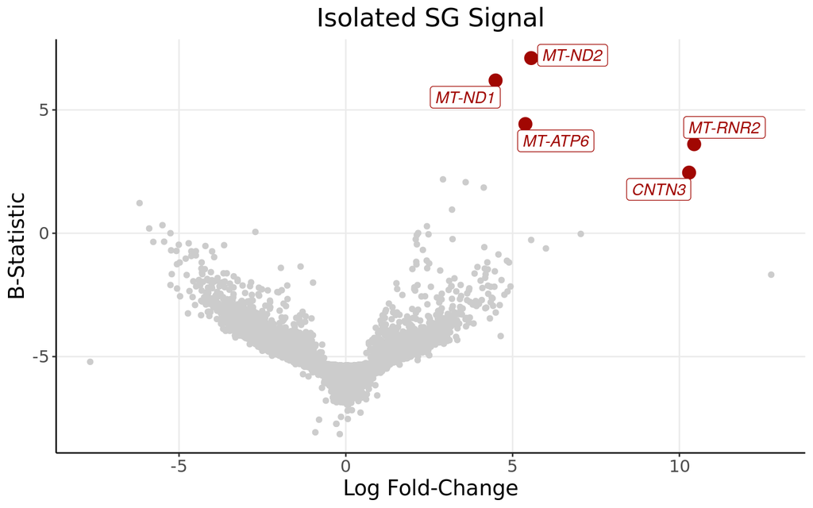

```r
write.table(x = DEGenes_complex,
            file = "~/Projects/StressGranules/SGPAPER/RealSGs/APadron.txt", sep="\t", col.names = TRUE, row.names = TRUE, quote=FALSE)

upmarkers <- as.data.frame(DEGenes_complex[DEGenes_complex$logFC>1 & DEGenes_complex$adj.P.Val<0.05,] )
downmarkers <- as.data.frame(DEGenes_complex[DEGenes_complex$logFC< -1 & DEGenes_complex$adj.P.Val<0.05,] )

ggplot(data=DEGenes_complex,
                 aes(x=logFC,
                     y=  B)) +
  geom_point(color="#CCCCCC")+
  theme_bw() + ylab("B-Statistic")+xlab("Log Fold-Change")+
  theme(axis.line = element_line(colour = "black"),
        panel.grid.minor = element_blank(),
        panel.border = element_blank(),
        panel.background = element_blank()) +
  ggtitle("Isolated SG Signal")+
  theme(plot.title = element_text(hjust = 0.5), plot.subtitle = element_text(hjust = 0.5)) +
  geom_point(data=upmarkers, aes(x=logFC, y=  B), color="#A10702",size=4)+
  geom_point(data=downmarkers, aes(x=logFC, y=  B), color="#03256C",size=4)+
  geom_label_repel(upmarkers[1:ndegs,] , mapping=aes(label=row.names(upmarkers)[1:ndegs]),size=4,point.padding=-0.5, color="#A10702",max.overlaps = 20, fontface="italic")+
  geom_label_repel(downmarkers[1:ndegs,] , mapping=aes(label=row.names(downmarkers)[1:ndegs]),size=4,point.padding=-0.5, color="#03256C",max.overlaps = 20, fontface="italic")+
  theme(text=element_text(size=15,  family="Arial MS"))
```

Althought not as clear, we see mitochondrial transcripts.

## Volcano Plot with Gene Length

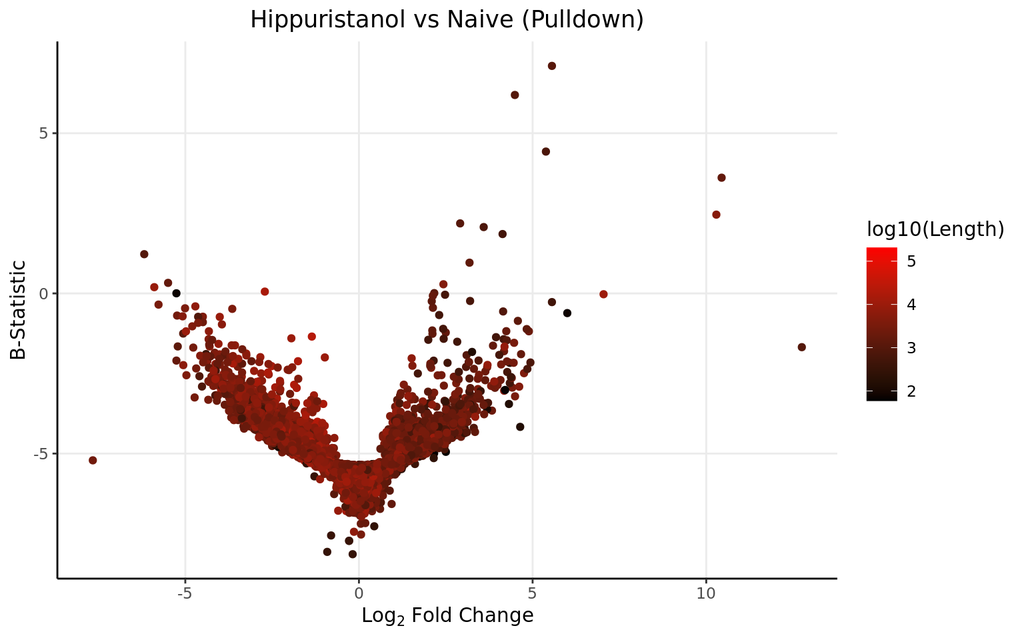

```r
DEGenes_complex$Gene <- row.names(DEGenes_complex)
colnames(genelength) <- c("Length","Gene")
DEGenes_complex <- merge(DEGenes_complex, genelength, by="Gene")

ggplot(data=DEGenes_complex,
                 aes(x=logFC,
                     y=  B)) +
  geom_point(aes(color=log10(Length)))+
  theme_bw() +
  theme(axis.line = element_line(colour = "black"),
        panel.grid.minor = element_blank(),
        panel.border = element_blank(),
        panel.background = element_blank()) +
  ggtitle("Hippuristanol vs Naive (Pulldown)")+ xlab(expression(Log[2] ~ Fold ~ Change)) + ylab("B-Statistic") +
  theme(plot.title = element_text(hjust = 0.5))  +
  scale_colour_gradient(low = "black", high = "red")+ theme(text=element_text(family = "Quicksand"))
```

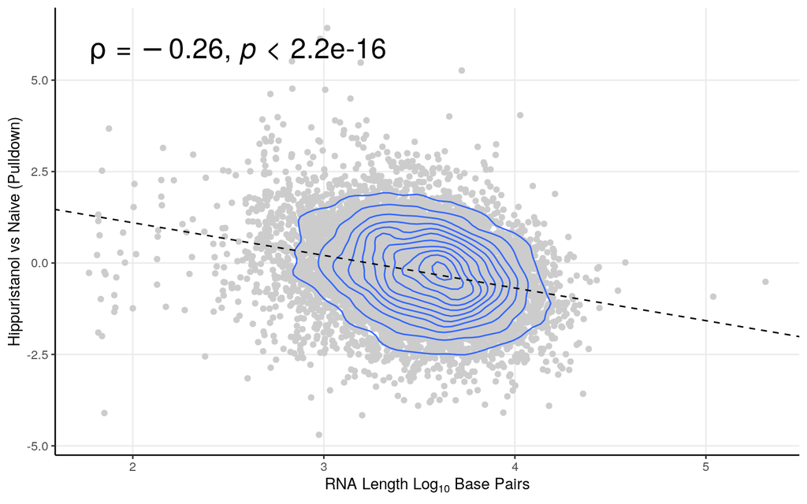

```r
smooth.SG <- lm(t~log10(Length), DEGenes_complex)
liner.SG <- rstandard(smooth.SG)
DEGenes_complex <-cbind(DEGenes_complex, liner.SG)
colnames(DEGenes_complex)[9] <- "Residuals"
row.names(DEGenes_complex) <- DEGenes_complex$Gene
linemarkers <- as.data.frame(DEGenes_complex[abs(DEGenes_complex$Residuals)>4,])

# Calculate the Spearman correlation coefficient
spearman_corr <- cor(DEGenes_complex$t, log10(DEGenes_complex$Length), method = "spearman")



ggplot(DEGenes_complex, aes(y=t, x=log10(Length))) + geom_point(color="#CCCCCC", alpha=1) +   theme_bw()+ geom_density_2d()+
 ylab("Hippuristanol vs Naive (Pulldown)") + xlab(expression(RNA ~ Length ~ Log[10] ~ Base ~ Pairs)) +
  theme(axis.line = element_line(colour = "black"),
        panel.grid.minor = element_blank(),
        panel.border = element_blank(),
        panel.background = element_blank()) +
  theme(plot.title = element_text(hjust = 0.5))  +
  geom_abline(slope=smooth.SG$coefficients[2], intercept = smooth.SG$coefficients[1], linetype = "dashed")+ stat_cor(method = "spearman", cor.coef.name = "rho",size=7)
```

Here, we have a negative lenght bias.

## Expression Graphs (Extra QC)

As an added control, lets plot these genes in regard to their expression, and contamination.

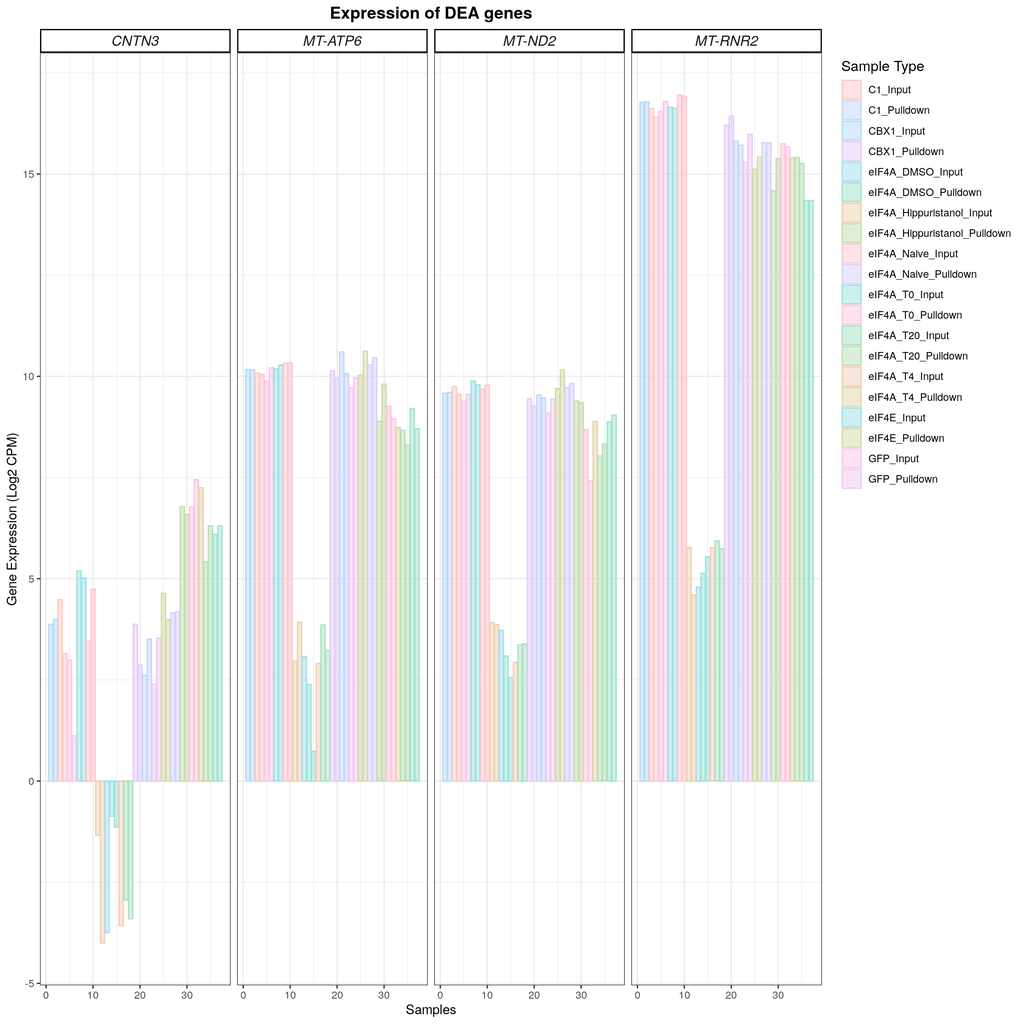

```r
# Define color palette
custom_palette <- qualitative_hcl(20, palette = "Pastel")
custom_palette <- sample(custom_palette, 20)


upmarkers <- as.data.frame(DEGenes_complex[DEGenes_complex$logFC>5 & DEGenes_complex$adj.P.Val<0.05,] )
downmarkers <- as.data.frame(DEGenes_complex[DEGenes_complex$logFC< -5 & DEGenes_complex$adj.P.Val<0.05,] )

finagenes <- rbind(upmarkers, downmarkers)

dfforexpression <- dfforpca
samplecodes <- data.frame(samples=row.names(dfforexpression), purity=c(1:nrow(dfforexpression)))
sampletype <- data.frame(samples=row.names(dfforexpression), sampletype=forall)
dfforexpression <- t(dfforexpression)
genesforexp <- dfforexpression[row.names(dfforexpression)%in%row.names(finagenes),]
genesforexp <- reshape2::melt(genesforexp)
colnames(genesforexp) <- c("Gene", "samples", "expression")
genesforexp <- merge(genesforexp, samplecodes, by="samples")
genesforexp <- merge(genesforexp, sampletype, by="samples")
genesforexp <- genesforexp[,-1]
genesforexp[,2] <- as.numeric(genesforexp[,2])
genesforexp[,1] <- as.character(genesforexp[,1])
genesforexp <- genesforexp[order(genesforexp$Gene),]


winnyplot <- ggplot(genesforexp, aes(x=purity, y=expression, fill=sampletype, colour=sampletype)) + geom_bar(position="dodge", stat="identity", alpha=0.5) + facet_wrap(.~ Gene, ncol=5)
winnyplot <- winnyplot + scale_fill_manual(name = "Sample Type", values = custom_palette) + scale_colour_manual(name = "Sample Type", values = custom_palette)
winnyplot <- winnyplot + theme_bw() + xlab("Samples") + ylab("Gene Expression (Log2 CPM)") + theme(
      strip.text.x = element_text(
        size = 12, face="italic"
        )) +
 theme(
   strip.background = element_rect(
     color="black", fill="#FFFFFF", size=1, linetype="solid"
     )
   ) + theme(
    #legend.position = c(.95, .40),
    legend.justification = c("right", "top"),
    legend.box.just = "right",
    ) + theme(legend.title = element_text(size = 12)) + ggtitle("Expression of DEA genes") + theme(plot.title = element_text(hjust = 0.5, size=14, face="bold"))
winnyplot
```

## GSEA

```r
#for all genes
DEGenes_complex <- DEGenes_complex[order(DEGenes_complex[,4]),]
gseatool <- DEGenes_complex[,4]
gseatool <- as.data.frame(gseatool)
colnames(gseatool)[1] <- "t"
gseatool[,2] <- DEGenes_complex$Gene
colnames(gseatool)[2] <- "Symbol"
gseatool <- gseatool[,c(2,1)]

vectorranks <- gseatool$t
names(vectorranks) <- gseatool$Symbol


#to load our pathways
hallmarks.gs <- msigdbr(species = "Homo sapiens", collection =  "H")

hallmarks.gsets <- hallmarks.gs %>% split(x = .$gene_symbol, f = .$gs_name)

for (set in names(hallmarks.gsets)){
  hallmarks.gsets[[set]] <- toupper(hallmarks.gsets[[set]])
}

hallmarks.res <- fgsea(pathways = hallmarks.gsets,
                       stats = vectorranks)
```

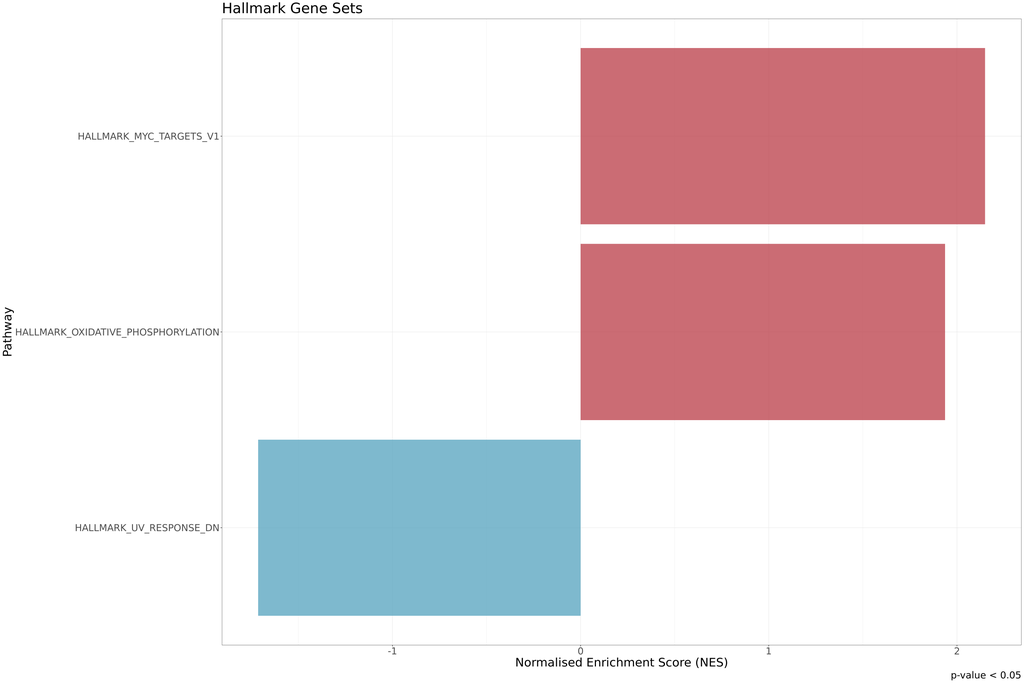

```r
hallmarks.res.tidy <- hallmarks.res %>%
  as_tibble() %>%
  arrange(desc(NES))

hallmarks.res.tidy %>%
  dplyr::select(-leadingEdge, -ES) %>%
  arrange(padj)

hallmark.sg.t <- hallmarks.res.tidy[,c(1,6)]
hallmark.sg.t <- as.data.frame(hallmark.sg.t)

#this small part is generic
thresh <- 0.05

#this one is no longer generic
data_to_plot <- hallmarks.res.tidy %>% filter(padj < thresh)

statvec <- c()
for (i in 1:nrow(data_to_plot)){
  if (data_to_plot[i,6] > 0){
    status <- "Upregulated"
  }
 else {
   status <- "Downregulated"
 }
statvec <- c(statvec, status)
}

data_to_plot$Status <- statvec

##-----HALMARK-----
gsea_plot_hall <- ggplot(data_to_plot, aes(reorder(pathway, NES), NES)) +
  geom_col(aes(fill= Status), alpha=0.75) + scale_fill_manual(values = c("#53A2BE","#BA3B46"), name = "Regulation Status", labels = c("Downregulated", "Upregulated"), breaks = c("Downregulated", "Upregulated")) +
  coord_flip() +
  labs(x="Pathway", y="Normalised Enrichment Score (NES)",
       title= "Hallmark Gene Sets",
       caption = paste0("p-value < ", thresh)) + theme(plot.title = element_text(hjust = 1)) +
  theme_bw() + theme(text=element_text(family = "Quicksand")) + theme(legend.position = "none")

gsea_plot_hall+
  theme(text=element_text(size=25,  family="Arial MS"))
```

[^1]: Disease Transcriptomics Group, Gulbenkian Institute of Molecular Medicine